# Titanic: Comparing Two Approaches for Missing Data

Harry Emeric

27 November, 2017

# 1 Introduction

Here I build on my previous Kernel (please see link below) to compare two different approaches to dealing with missing data. The first approach is to impute missing data, for example making a prediction from the available variables. The second method is to train a separate model for each comination of missing fields we observe in the dataset. My aim is to see which approach has higher predictive accuracy. I made a start on this previously by doing this just for the “Age” variable, and found that it did not improve accuracy, although this could be due to lost information by binning “Age” into brackets. In this work I look to generalise this approach to all variables.

https://www.kaggle.com/harryem/feature-engineering-on-the-titanic-for-0-81339

## 1.1 The problem

Given test features $X_{TEST} \in /R^{n * k}$ is a matrix of n test examples and k features and vector $y_{TEST} \in \{0,1\}^n$ classifying survived (1) or did not survive (0), our aim is to estimate a function f such that $y = f(x)$ which minimises misclassification, that is
$$min \sum_{i=1}^{n}(y_i - f(x_i))^2$$
where $f(x_i)$ is the prediction for the ith test example and $y_i$ is the ith classification, which is known only by the Kaggle administrators.

## 1.2 Loading libraries and data

Loading libraries

```r
library(ggplot2) #charting
library(scales) #charting
library(grid) #charting
library(plyr) #data wrangling
library(dplyr) #data wrangling
library(tidyr) #data wrangling
library(Hmisc) #data wrangling
library(mice) #imputing variables
library(randomForest) #modelling
library(caret) #modelling
traindata <- read.csv('../input/train.csv', stringsAsFactors = F)
testdata <- read.csv('../input/test.csv', stringsAsFactors = F)

c(object.size(traindata),object.size(testdata))
```

```
## [1] 179136  86008
```

```r
testdata$Survived <- "NA"
merged <- rbind(traindata,testdata)

length(unique(merged$PassengerId)) == length(merged$PassengerId) # check no duped entries
```

```
## [1] TRUE
```

The data is small so performance shouldn’t be an issue.

I want to combine training and test sets because this makes it easier to perform the # same operations on both sets

# 2 Initial Data Wrangling and Exploratory Data Analysis

For detailed impormation about features check here https://www.kaggle.com/c/titanic/data

```r
head(merged)
```

```
##   PassengerId Survived Pclass
## 1           1        0      3
## 2           2        1      1
## 3           3        1      3
## 4           4        1      1
## 5           5        0      3
## 6           6        0      3
##                                                  Name    Sex Age SibSp
## 1                             Braund, Mr. Owen Harris   male  22     1
## 2 Cumings, Mrs. John Bradley (Florence Briggs Thayer) female  38     1
## 3                              Heikkinen, Miss. Laina female  26     0
## 4        Futrelle, Mrs. Jacques Heath (Lily May Peel) female  35     1
## 5                            Allen, Mr. William Henry   male  35     0
## 6                                    Moran, Mr. James   male  NA     0
##   Parch           Ticket    Fare Cabin Embarked
## 1     0        A/5 21171  7.2500              S
## 2     0         PC 17599 71.2833   C85        C
## 3     0 STON/O2. 3101282  7.9250              S
## 4     0           113803 53.1000  C123        S
## 5     0           373450  8.0500              S
## 6     0           330877  8.4583              Q
```

```r
colSums(is.na(merged))
```

```
## PassengerId    Survived      Pclass        Name         Sex         Age
##           0           0           0           0           0         263
##       SibSp       Parch      Ticket        Fare       Cabin    Embarked
##           0           0           0           1           0           0
```

```r
colSums(merged=="")
```

```
## PassengerId    Survived      Pclass        Name         Sex         Age
##           0           0           0           0           0          NA
##       SibSp       Parch      Ticket        Fare       Cabin    Embarked
##           0           0           0          NA        1014           2
```

There is missing data in the Age, Fare, Cabin and Embarked varibles, and the aim of this piece is to explore and contrast various ways of approaching this issue.

We need to add a field classifying which data are missing for each element.

```r
a <- colSums(is.na(testdata))+colSums(testdata=="")
a <- names(a[is.na(a)|a!=0])
a
```

```
## [1] "Age"   "Fare"  "Cabin"
```

```r
missing <- c()

for (i in a) {
  missing <- paste(missing,as.integer(!is.na(merged[i])^!merged[i]==""),sep="")
                 }

merged[missing=="100",]
```

```
##      PassengerId Survived Pclass               Name  Sex  Age SibSp Parch
## 1044        1044       NA      3 Storey, Mr. Thomas male 60.5     0     0
##      Ticket Fare Cabin Embarked
## 1044   3701   NA              S
```

```r
#There is only one example of this combination and its in the test set. I will discuss this later.

table(missing)
```

```
## missing
## 010 011 100 110 111
## 240  23   1 773 272
```

```r
merged$Missing <- missing
```

0 means missing and 1 means observed, so for example “100” means Age was observed, Fare and Cabin were not.

There are five different combinations of missing variables in the data, so the approach will be train a separate model for each of these five possibilities

First let’s review the charts of survivor trends by age, class, gender.

## 2.1 Class & Sex

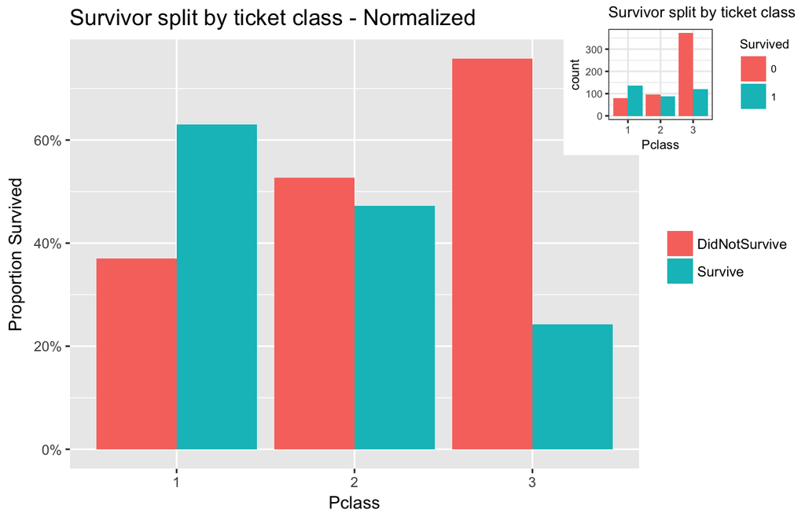

```r
merged$Pclass <- as.factor(merged$Pclass)
merged$Sex <- as.factor(merged$Sex)

g <- ggplot(merged[1:891,], aes(x=Pclass,fill=factor(Survived))) + geom_bar(pos  = "dodge") + labs(fill = "Survived",title="Survivor split by ticket class")

dftemp <- merged[1:891,] %>%
    group_by(Pclass) %>%
    summarise(Survive = sum(Survived == 1) / n(),
              DidNotSurvive = sum(Survived == 0) / n()) %>%
    gather(key = Group,value = Surv,Survive:DidNotSurvive)

gn <- ggplot(dftemp, aes(x = Pclass,
                            y = Surv,
                            fill = as.factor(Group))) +
    geom_bar(position = "dodge",stat = "identity") +
    scale_y_continuous(labels = percent_format()) +
    labs(y = "Proportion Survived",title="Survivor split by ticket class - Normalized") +
    theme(legend.title=element_blank(), plot.title = element_text(size=14))


vp <- viewport(width = 0.3, height = 0.3, x = 0.85,
     y = 0.85)

print(gn)
theme_set(theme_bw(base_size = 8))
print(g,vp=vp)
```

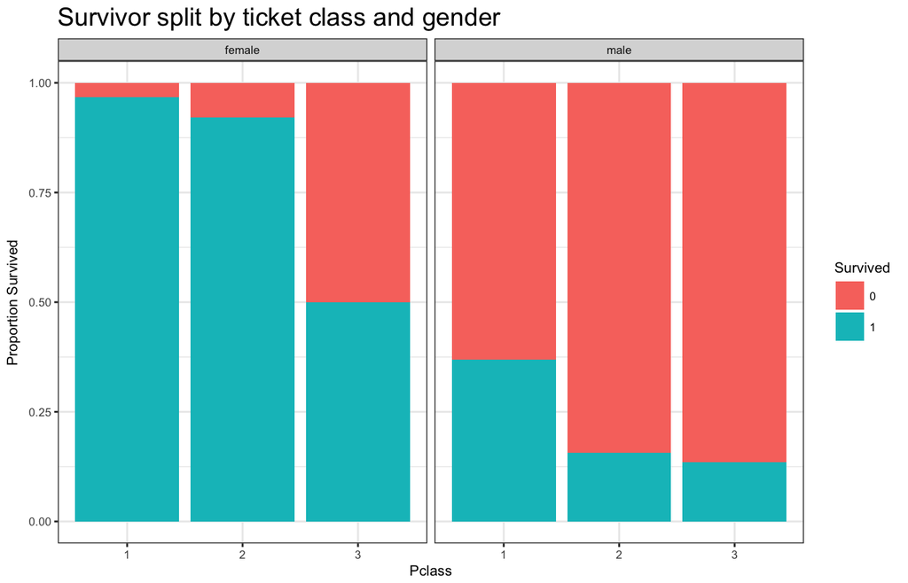

```r
g <- ggplot(merged[1:891,], aes(x=Pclass,fill=factor(Survived))) + geom_bar(pos  = "fill") + facet_wrap(~Sex) + labs(y = "Proportion Survived",fill = "Survived",title="Survivor split by ticket class and gender")
g + theme(plot.title = element_text(size=14))
```

As expected, higher class of ticket and female gender seem to be good positive predictors of survival.

## 2.2 Age

I would like to segment by age and create a new feature for age bracket for visualisation, and to see if this improves model performance relative to using individual ages.

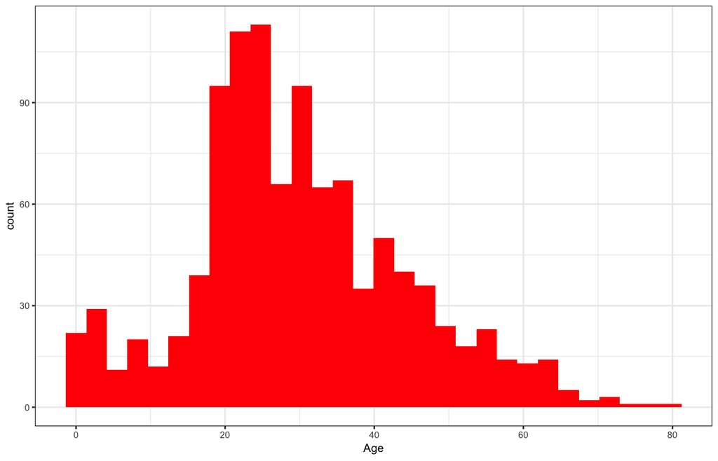

```r
qplot(merged$Age,fill=I("red"),xlab = "Age")
```

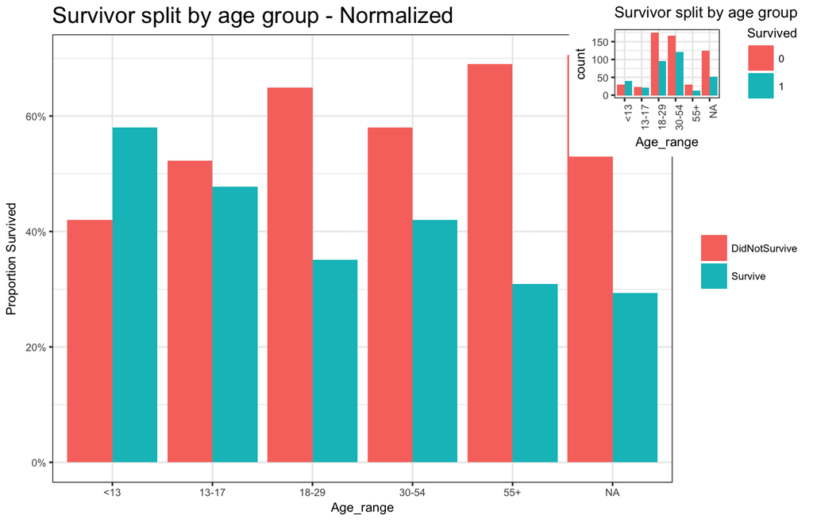

```r
agebrackets <- c(0,13,18,30,55)
merged$Agebracket <- findInterval(merged$Age,agebrackets)

agetable <- data.frame(Agebracket=c(1,2,3,4,5),Age_range=c("<13","13-17","18-29","30-54","55+"))
merged <- join(merged,agetable,by="Agebracket")
merged$Agebracket <- as.factor(merged$Agebracket)

g <- ggplot(merged[1:891,], aes(x=Age_range,fill=factor(Survived))) + geom_bar(pos="dodge") + labs(fill = "Survived",title="Survivor split by age group") + theme(axis.text.x = element_text(angle = 90, hjust = 1))

dftemp <- merged[1:891,] %>%
    group_by(Age_range) %>%
    summarise(Survive = sum(Survived == 1) / n(),
              DidNotSurvive = sum(Survived == 0) / n()) %>%
    gather(key = Group,value = Surv,Survive:DidNotSurvive)

gn <- ggplot(dftemp, aes(x = Age_range,
                            y = Surv,
                            fill = as.factor(Group))) +
    geom_bar(position = "dodge",stat = "identity") +
    scale_y_continuous(labels = percent_format()) +
    labs(y = "Proportion Survived",title="Survivor split by age group - Normalized") +
    theme(legend.title=element_blank(),plot.title = element_text(size=14))

vp <- viewport(width = 0.3, height = 0.3, x = 0.85,
     y = 0.85)

print(gn)
theme_set(theme_bw(base_size = 8))
print(g,vp=vp)
```

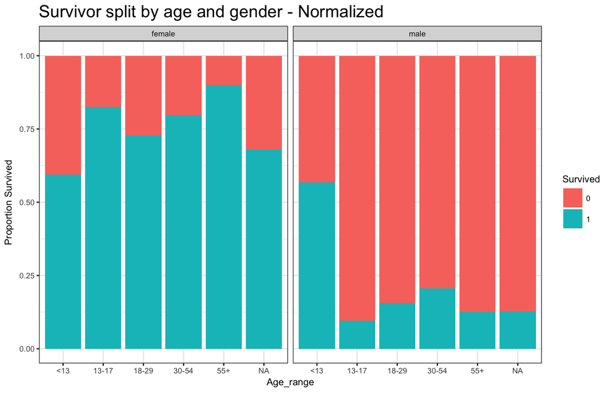

```r
g <- ggplot(merged[1:891,], aes(x=Age_range,fill=factor(Survived))) + geom_bar(pos="fill") + labs(y = "Proportion Survived",fill = "Survived",title="Survivor split by age and gender - Normalized") + facet_wrap(~Sex)
g + theme(plot.title = element_text(size=14))
```

Age bracket seems to give a lot of information, with youger generally having a better chance of survival. Interestingly elderly women has a very good chance of survival whereas elderly men had a very bad chance so it looks like this is a useful division.

# 3 Feature Engineering, Cleaning and Completing the Data

I now need to impute the missing data for that analysis, as I already have the pre imputation field “Missing” I can subset the data based on the what was originally missing. Each new feature is based off a single feature in the original data, so we can map that according to the “Missing” field.

The Cabin variable has many missing entries. I’m guessing this isn’t just missing data, but that a lot of people didn’t have a Cabin. So I shall turning this into a 2 factor variable, has / does not have cabin.

In my previous work I binned some of the variables together for fear of overfitting. However I saw little evidence of overfitting, for example that regularizing the logistic regression model provided very little improvement. As such I will avoid binning variables such as Age and Title, apart from for visualisation purposes.

## 3.1 Cabin

```r
head(merged$Cabin,30)
```

```
##  [1] ""            "C85"         ""            "C123"        ""
##  [6] ""            "E46"         ""            ""            ""
## [11] "G6"          "C103"        ""            ""            ""
## [16] ""            ""            ""            ""            ""
## [21] ""            "D56"         ""            "A6"          ""
## [26] ""            ""            "C23 C25 C27" ""            ""
```

```r
length(unique(merged$Cabin))/length(merged$Cabin) ## only 14% are unique so there are a lot shared.
```

```
## [1] 0.1428571
```

```r
merged$Cabin[28] # this looks strange, multiple cabins on one ticket
```

```
## [1] "C23 C25 C27"
```

```r
subset(merged,Cabin == "C23 C25 C27") # it was one family, the Fortunes
```

```
##     PassengerId Survived Pclass                                Name    Sex
## 28           28        0      1      Fortune, Mr. Charles Alexander   male
## 89           89        1      1          Fortune, Miss. Mabel Helen female
## 342         342        1      1      Fortune, Miss. Alice Elizabeth female
## 439         439        0      1                   Fortune, Mr. Mark   male
## 945         945       NA      1          Fortune, Miss. Ethel Flora female
## 961         961       NA      1 Fortune, Mrs. Mark (Mary McDougald) female
##     Age SibSp Parch Ticket Fare       Cabin Embarked Missing Agebracket
## 28   19     3     2  19950  263 C23 C25 C27        S     111          3
## 89   23     3     2  19950  263 C23 C25 C27        S     111          3
## 342  24     3     2  19950  263 C23 C25 C27        S     111          3
## 439  64     1     4  19950  263 C23 C25 C27        S     111          5
## 945  28     3     2  19950  263 C23 C25 C27        S     111          3
## 961  60     1     4  19950  263 C23 C25 C27        S     111          5
##     Age_range
## 28      18-29
## 89      18-29
## 342     18-29
## 439       55+
## 945     18-29
## 961       55+
```

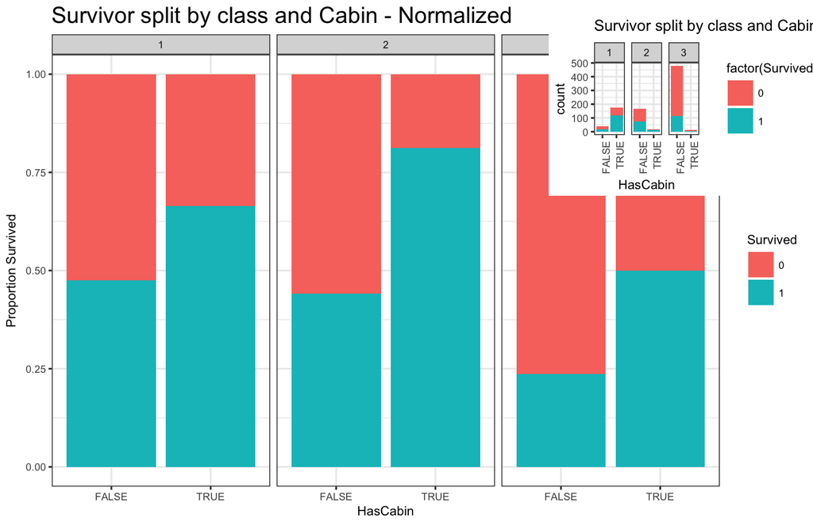

```r
merged$HasCabin <- as.factor(!(merged$Cabin==""))

g <- ggplot(merged[1:891,], aes(x=HasCabin,fill=factor(Survived))) + geom_bar()
g <- g +facet_wrap(~Pclass) + labs(title="Survivor split by class and Cabin") + theme(axis.text.x = element_text(angle = 90, hjust = 1))

gn <- ggplot(merged[1:891,], aes(x=HasCabin,fill=factor(Survived))) + geom_bar(pos="fill")
gn <- gn +facet_wrap(~Pclass) +labs(y = "Proportion Survived",fill = "Survived",title="Survivor split by class and Cabin - Normalized") + theme(plot.title = element_text(size=14))

vp <- viewport(width = 0.35, height = 0.35, x = 0.85,
     y = 0.8)

print(gn)
theme_set(theme_bw(base_size = 8))
print(g,vp=vp)
```

As expected few people in Class 2 and 3 had cabins, but actually those who did had a good chance of survival. Helping to capture the smaller number who survived from lower classes should be very additive.

## 3.2 Fare

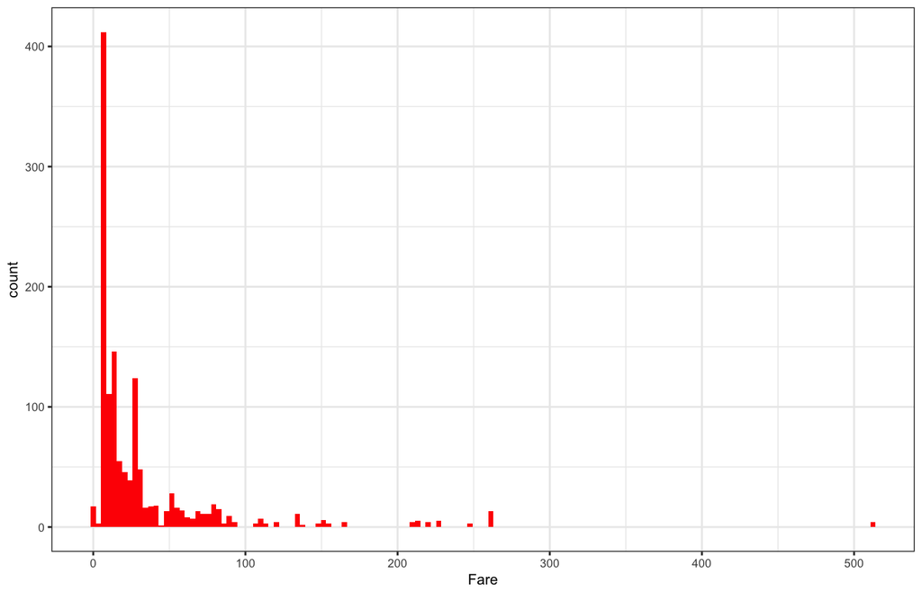

```r
qplot(merged$Fare,bins=150,fill=I("red"),xlab = "Fare")
```

There doesn’t seem to be natural brackets here unlike age, so I will just split in equal groups. There is one missing entry for Fare, I will impute the average Fare for his Pclass.

```r
a <- subset(merged,is.na(merged$Fare))
a
```

```
##      PassengerId Survived Pclass               Name  Sex  Age SibSp Parch
## 1044        1044       NA      3 Storey, Mr. Thomas male 60.5     0     0
##      Ticket Fare Cabin Embarked Missing Agebracket Age_range HasCabin
## 1044   3701   NA              S     100          5       55+    FALSE
```

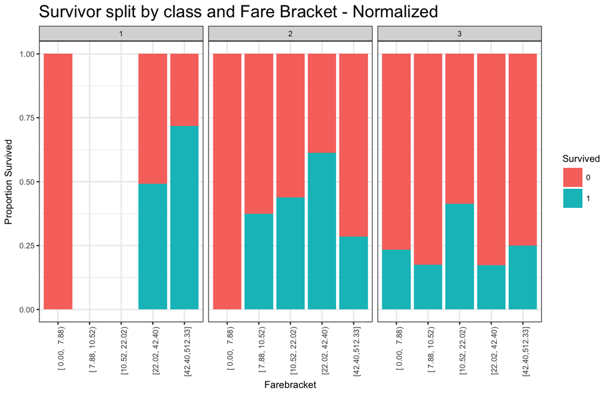

```r
merged[a[,1],]$Fare <- mean(subset(merged,Pclass==3)$Fare,na.rm=TRUE)

merged$Farebracket <- as.factor(cut2(merged$Fare,g=5))

g <- ggplot(merged[1:891,], aes(x=Farebracket,fill=factor(Survived))) + geom_bar(pos="fill")
g <- g +facet_wrap(~Pclass) + labs(y = "Proportion Survived",fill = "Survived",title="Survivor split by class and Fare Bracket - Normalized")
g <- g + theme(axis.text.x = element_text(angle = 90, hjust = 1),plot.title = element_text(size=14))
g
```

```r
subset(merged,Fare==0)
```

```
##      PassengerId Survived Pclass                                  Name
## 180          180        0      3                   Leonard, Mr. Lionel
## 264          264        0      1                 Harrison, Mr. William
## 272          272        1      3          Tornquist, Mr. William Henry
## 278          278        0      2           Parkes, Mr. Francis "Frank"
## 303          303        0      3       Johnson, Mr. William Cahoone Jr
## 414          414        0      2        Cunningham, Mr. Alfred Fleming
## 467          467        0      2                 Campbell, Mr. William
## 482          482        0      2      Frost, Mr. Anthony Wood "Archie"
## 598          598        0      3                   Johnson, Mr. Alfred
## 634          634        0      1         Parr, Mr. William Henry Marsh
## 675          675        0      2            Watson, Mr. Ennis Hastings
## 733          733        0      2                  Knight, Mr. Robert J
## 807          807        0      1                Andrews, Mr. Thomas Jr
## 816          816        0      1                      Fry, Mr. Richard
```

[output cut: 39 more lines]

This is more useful than expected, it does seem to split out the survivors within a class quite nicely. There were 17 people who paid 0 fare including some in first class - I don’t think its worth creating a separate category here though.

One group paid over $500.

```r
head(order(merged$Fare,decreasing = TRUE))
```

```
## [1]  259  680  738 1235   28   89
```

```r
merged[259,]
```

```
##     PassengerId Survived Pclass             Name    Sex Age SibSp Parch
## 259         259        1      1 Ward, Miss. Anna female  35     0     0
##       Ticket     Fare Cabin Embarked Missing Agebracket Age_range HasCabin
## 259 PC 17755 512.3292              C     110          4     30-54    FALSE
##        Farebracket
## 259 [42.40,512.33]
```

```r
subset(merged,Fare==merged$Fare[259])
```

```
##      PassengerId Survived Pclass
## 259          259        1      1
## 680          680        1      1
## 738          738        1      1
## 1235        1235       NA      1
##                                                                 Name
## 259                                                 Ward, Miss. Anna
## 680                               Cardeza, Mr. Thomas Drake Martinez
## 738                                           Lesurer, Mr. Gustave J
## 1235 Cardeza, Mrs. James Warburton Martinez (Charlotte Wardle Drake)
##         Sex Age SibSp Parch   Ticket     Fare       Cabin Embarked Missing
## 259  female  35     0     0 PC 17755 512.3292                    C     110
## 680    male  36     0     1 PC 17755 512.3292 B51 B53 B55        C     111
## 738    male  35     0     0 PC 17755 512.3292        B101        C     111
## 1235 female  58     0     1 PC 17755 512.3292 B51 B53 B55        C     111
##      Agebracket Age_range HasCabin    Farebracket
## 259           4     30-54    FALSE [42.40,512.33]
## 680           4     30-54     TRUE [42.40,512.33]
## 738           4     30-54     TRUE [42.40,512.33]
## 1235          5       55+     TRUE [42.40,512.33]
```

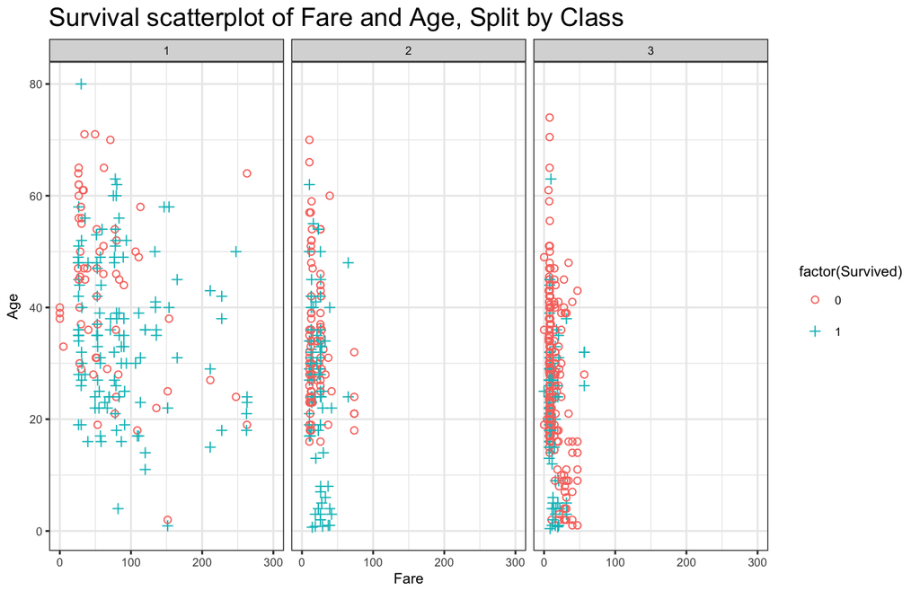

```r
g <- ggplot(merged[1:891,],aes(x=Fare,y=Age,shape=factor(Survived),color=factor(Survived))) + geom_point() + scale_shape_manual(values=c(1,3)) + xlim(0, 300)

g <- g +facet_wrap(~Pclass) + labs(fill="Survived",title="Survival scatterplot of Fare and Age, Split by Class") + theme(plot.title = element_text(size=14))
g
```

This is a useful chart and shows some clustering of survivors in Class 2 who have low Age and Fare.

## 3.3 Title

```r
merged$Title <- gsub('(.*, )|(\\..*)', '', merged$Name)

count(merged,Title)
```

```
## # A tibble: 18 x 2
##           Title     n
##           <chr> <int>
##  1         Capt     1
##  2          Col     4
##  3          Don     1
##  4         Dona     1
##  5           Dr     8
##  6     Jonkheer     1
##  7         Lady     1
##  8        Major     2
##  9       Master    61
## 10         Miss   260
## 11         Mlle     2
## 12          Mme     1
## 13           Mr   757
## 14          Mrs   197
## 15           Ms     2
## 16          Rev     8
## 17          Sir     1
## 18 the Countess     1
```

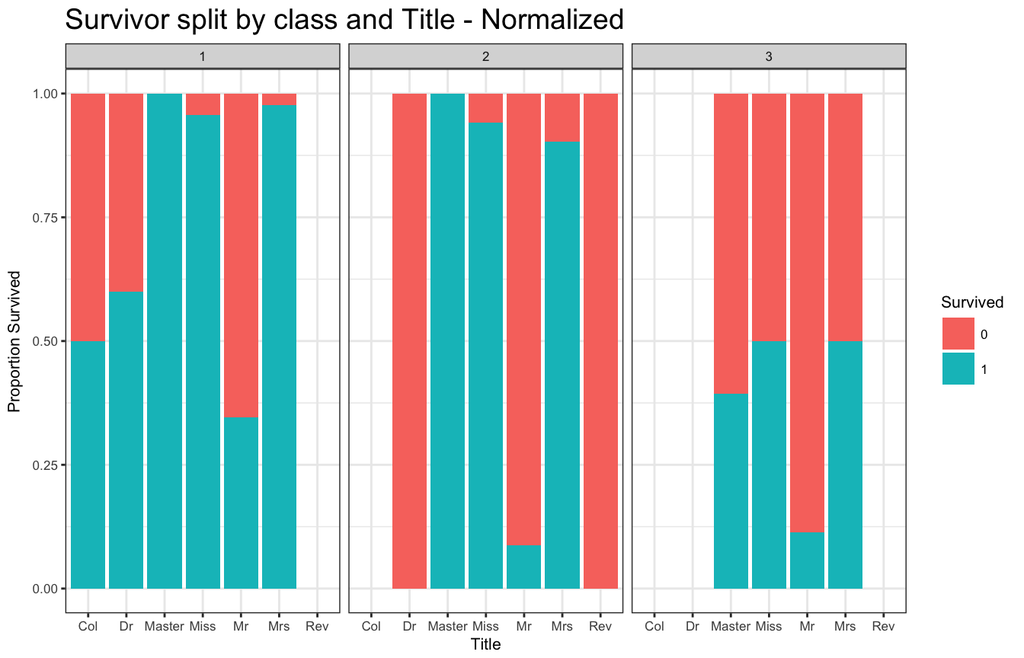

```r
merged$Title <- as.factor(merged$Title)

a <- count(merged,Title)

a <- a[a$n>2,]$Title
dftemp <- merged[1:891,]
dftemp <- dftemp[dftemp$Title %in% a,]

g <- ggplot(dftemp, aes(x=Title,fill=factor(Survived))) + geom_bar(pos="fill")
g <- g +facet_wrap(~Pclass) + labs(y = "Proportion Survived",fill = "Survived",title="Survivor split by class and Title - Normalized") + theme(plot.title = element_text(size=14))
g
```

This does appear to be useful on the normalized scale.

## 3.4 Name

This added very little to my prior analysis so I will omit here.

## 3.5 Ticketsize variable

Create a variable for number of people on a single tickt to give a count for group size.

```r
merged <- ddply(merged,.(Ticket),transform,Ticketsize=length(Ticket))
merged$Ticketsize <- as.factor(merged$Ticketsize)
merged <- merged[order(merged$PassengerId),] # ddply mixes up order
```

## 3.6 Embarked

Move the two cases where this is unmarked to the modal case, “S”

```r
count(merged,Embarked)
```

```
## # A tibble: 4 x 2
##   Embarked     n
##      <chr> <int>
## 1              2
## 2        C   270
## 3        Q   123
## 4        S   914
```

```r
subset(merged,Embarked == "")
```

```
##    PassengerId Survived Pclass                                      Name
## 59          62        1      1                       Icard, Miss. Amelie
## 60         830        1      1 Stone, Mrs. George Nelson (Martha Evelyn)
##       Sex Age SibSp Parch Ticket Fare Cabin Embarked Missing Agebracket
## 59 female  38     0     0 113572   80   B28              111          4
## 60 female  62     0     0 113572   80   B28              111          5
##    Age_range HasCabin    Farebracket Title Ticketsize
## 59     30-54     TRUE [42.40,512.33]  Miss          2
## 60       55+     TRUE [42.40,512.33]   Mrs          2
```

```r
merged[c(62,830),"Embarked"] <- "S"
merged$Embarked <- as.factor(merged$Embarked)
```

## 3.7 Age

To begin with, I want to use the mice library to impute the missing ages. Then I want to check if we get improvement by splitting data as explained above. One issue with using other variables to impute missing data is that the variables used in that model are then double counted for those entries.

```r
m1 <- merged[, !names(merged) %in% c("Agebracket","Age_range")]
mice_ages <- mice(m1[, !names(m1) %in% c('PassengerId','Name','Ticket','Cabin','Family','Surname','Survived','Missing')], method='rf',seed = 1234)
mice_out <- mice::complete(mice_ages)

merged$Age <- mice_out$Age
merged$Agebracket <- findInterval(merged$Age,agebrackets)
merged <- join(merged,agetable,by="Agebracket")

colSums(is.na(merged))+colSums(merged=="")
```

```
## PassengerId    Survived      Pclass        Name         Sex         Age
##           0           0           0           0           0           0
##       SibSp       Parch      Ticket        Fare       Cabin    Embarked
##           0           0           0           0        1014           0
##     Missing  Agebracket   Age_range    HasCabin Farebracket       Title
##           0           0          NA           0           0           0
##  Ticketsize   Age_range
##           0           0
```

# 4 Model Fitting and Comparison

First split the data back into training/ CV and set we use for submission,

```r
mergedtrain <- merged[1:891,]
mergedtest <- merged[892:1309,]
mergedtrain$Survived <- as.factor(traindata$Survived)

set.seed(414)
inTrain<- createDataPartition(y=mergedtrain$Survived,p=0.75, list=FALSE)
train <- mergedtrain[inTrain,]
test <- mergedtrain[-inTrain,]
```

For each of these comparisons I will use random forest models as these were the best performing models in my prior analysis.

## 4.1 Age Variable and the effect of Grouping

```r
set.seed(414)

rf_agegroups <- randomForest(factor(Survived) ~ Pclass + Sex + Farebracket + Agebracket + HasCabin + Ticketsize + Embarked + Title,
                       data = mergedtrain ,na.action = na.pass,nodesize=20)

rf_agegroups
```

```
##
## Call:
##  randomForest(formula = factor(Survived) ~ Pclass + Sex + Farebracket +      Agebracket + HasCabin + Ticketsize + Embarked + Title, data = mergedtrain,      nodesize = 20, na.action = na.pass)
##                Type of random forest: classification
##                      Number of trees: 500
## No. of variables tried at each split: 2
##
##         OOB estimate of  error rate: 16.27%
## Confusion matrix:
##     0   1 class.error
## 0 498  51  0.09289617
## 1  94 248  0.27485380
```

```r
rf_age <- randomForest(factor(Survived) ~ Pclass + Sex + Farebracket + Age + HasCabin + Ticketsize + Embarked + Title,
                       data = mergedtrain ,na.action = na.pass,nodesize=20)

rf_age
```

```
##
## Call:
##  randomForest(formula = factor(Survived) ~ Pclass + Sex + Farebracket +      Age + HasCabin + Ticketsize + Embarked + Title, data = mergedtrain,      nodesize = 20, na.action = na.pass)
##                Type of random forest: classification
##                      Number of trees: 500
## No. of variables tried at each split: 2
##
##         OOB estimate of  error rate: 16.72%
## Confusion matrix:
##     0   1 class.error
## 0 496  53  0.09653916
## 1  96 246  0.28070175
```

```r
rf_age$confusion
```

```
##     0   1 class.error
## 0 496  53  0.09653916
## 1  96 246  0.28070175
```

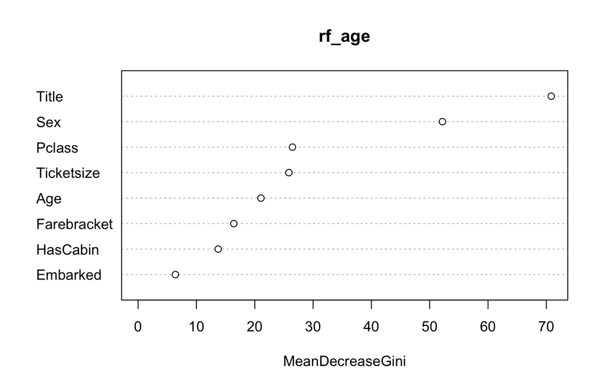

```r
varImpPlot(rf_age)
```

```r
importance(rf_age)
```

```
##             MeanDecreaseGini
## Pclass             26.468040
## Sex                52.183718
## Farebracket        16.405925
## Age                21.066494
## HasCabin           13.733466
## Ticketsize         25.850058
## Embarked            6.391301
## Title              70.837349
```

## 4.2 Generalised Model fit based on which variables are missing.

This approach references Goodfellow et al. “Deep Learning”, information can be found on page 98 under the section entitled “Classification with missing inputs”.

http://www.deeplearningbook.org/contents/ml.html

```r
unique(merged$Missing)
```

```
## [1] "110" "111" "010" "011" "100"
```

```r
dftemp <- mergedtrain[,c("Survived","Pclass","Sex","Fare","Age","HasCabin","Ticketsize","Embarked","Title","Missing")]

rf110 <- randomForest(factor(Survived) ~ .,
                        data = subset(dftemp[,!names(dftemp) %in% c("HasCabin")],dftemp$Missing=="110"))

rf111 <- randomForest(factor(Survived) ~ .,
                        data = subset(dftemp[,!names(dftemp) %in% c()],dftemp$Missing=="111"))

rf010 <- randomForest(factor(Survived) ~ .,
                        data = subset(dftemp[,!names(dftemp) %in% c("Age","HasCabin")],dftemp$Missing=="010"))

rf011 <- randomForest(factor(Survived) ~ .,
                        data = subset(dftemp[,!names(dftemp) %in% c("Age")],dftemp$Missing=="011"))

rf100 <- rf111

rf110$confusion
```

```
##     0   1 class.error
## 0 335  29  0.07967033
## 1  59 106  0.35757576
```

```r
rf111$confusion
```

```
##    0   1 class.error
## 0 41  19   0.3166667
## 1 22 103   0.1760000
```

```r
rf010$confusion
```

```
##     0  1 class.error
## 0 108  9  0.07692308
## 1  12 29  0.29268293
```

```r
rf011$confusion
```

```
##   0 1 class.error
## 0 7 1   0.1250000
## 1 3 8   0.2727273
```

# 5 Evaluation and submission

```r
p110 <- predict(rf110,mergedtest[mergedtest$Missing=="110",])
p111 <- predict(rf110,mergedtest[mergedtest$Missing=="111",])
p010 <- predict(rf110,mergedtest[mergedtest$Missing=="010",])
p011 <- predict(rf110,mergedtest[mergedtest$Missing=="011",])
p100 <- predict(rf110,mergedtest[mergedtest$Missing=="100",])
```

# 6 Evaluation and submission

Finally, I prepare the submission file to send to Kaggle.

```r
submission <- rbind(data.frame(PassengerId=names(p110),Survived=p110),data.frame(PassengerId=names(p111),Survived=p111),data.frame(PassengerId=names(p010),Survived=p010),data.frame(PassengerId=names(p011),Survived=p011),data.frame(PassengerId=names(p100),Survived=p100))

if(!file.exists("./predictions.csv")) {
        write.csv(submission, file = "./predictions.csv",row.names = F)}
```

This submission obtained 0.79425 accuracy, which is a decent amount worse than the 0.81339 I obtained from imputing variables and running a single random forest model. Lookined at some of the individual confusion matrices for the models, I expect this is because the training data isn’t large enough to split into so many partitions. I would be interested to see how this approach performs on a larger dataset.